# Lab Assignment One: Exploring Table Data

- Yongbin Huang
- Minjie Geng
- Tim Liu

# **1. Business Understanding**

What factors influence customer engagement in insurance campaign?

Main task would be predicting “campaign_engagement” or “engagement_level” from other features The primary business objective of this project is to increase company revenue by boosting customer participation in our insurance campaigns. To achieve this, we need to understand the key factors that influence customer engagement and identify actionable strategies to improve it.

This analysis focuses on a dataset of 16 features, which includes both numerical and categorical characteristics of the customers. By visualizing the relationships between these features, we can understand their impact on campaign effectiveness.

Ultimately, the insights from this analysis will empower company leadership to make more effective, data-driven decisions. The goal is to provide the team with clear recommendations to optimize future campaigns and define actionable next steps that will drive higher customer engagement and, in turn, increase our financial returns.

Question Of Interest:

- **How is timing impacting campaign effectiveness?**
- **How is people's background impacting campaign effectiveness?**
- **How does user response behavior impact campaign effectiveness?**

Citation of the dataset

> insurance_campaign_data: https://huggingface.co/datasets/nprak26/insurance-campaign-data

# **2. Data Understanding**

## **2.1 Data Description**

```python
import numpy as np
# load the insurance_campaign dataset
import pandas as pd

df = pd.read_csv("hf://datasets/nprak26/insurance-campaign-data/insurance_campaign_data_original_20250720_140142.csv")

pd.set_option('display.max_columns', None)
pd.set_option('display.max_rows', None)

print(df[['age', 'income','education_level', 'occupation', 'household_size', 'marital_status', 'life_stage', 'owns_home', 'num_vehicles', 'owns_business', 'region', 'regional_risk_score']].describe())
print(df[['education_level', 'occupation',  'marital_status', 'life_stage',  'region']].describe())
print(df[['previous_campaigns_received', 'previous_responses', 'response_rate_historical', 'website_visits_last_30d', 'mobile_app_usage_score', 'email_open_rate', 'quote_requests_last_year', 'quote_completion_rate']].describe())
print(df[['service_calls_last_year', 'claims_last_3_years', 'has_auto_policy', 'has_home_policy', 'has_life_policy', 'has_health_policy', 'has_commercial_policy', 'total_policies', 'policy_tenure_months', 'months_to_renewal']].describe())
print(df[['vehicle_value_total', 'driving_score', 'home_value', 'home_age_years', 'dependents_count', 'financial_obligations_score', 'campaign_date', 'last_policy_purchase_days', 'last_interaction_days', 'recent_life_event']].describe())
print(df[['recent_life_event','recent_life_event_encoded']].describe())
print(df[['life_event_recency_days', 'campaign_month', 'campaign_quarter', 'local_unemployment_rate', 'local_income_growth_rate', 'housing_market_index', 'channel_preference_digital', 'price_sensitivity_score', 'brand_loyalty_score']].describe())
print(df[['trust_score', 'recency_score', 'frequency_score', 'monetary_value_score', 'auto_risk_exposure', 'home_risk_exposure', 'life_risk_exposure', 'auto_coverage_gap', 'home_coverage_gap', 'life_coverage_gap', 'campaign_engagement']].describe())
print(df[['engagement_level', 'education_level_encoded', 'occupation_encoded', 'marital_status_encoded', 'life_stage_encoded', 'region_encoded', 'engagement_level_encoded']].describe())
```

```
                age         income  household_size     owns_home  \
count  15000.000000   15000.000000    15000.000000  15000.000000
mean      44.761667   59235.324533        2.465533      0.654867
std       14.445714   37322.985183        1.253788      0.475428
min       18.000000   25000.000000        1.000000      0.000000
25%       34.000000   32454.750000        2.000000      0.000000
50%       45.000000   49090.500000        2.000000      1.000000
75%       55.000000   73578.250000        3.000000      1.000000
max       85.000000  500000.000000        6.000000      1.000000

       num_vehicles  owns_business  regional_risk_score
count  15000.000000   15000.000000         15000.000000
mean       1.807333       0.148800             1.112809
std        1.312832       0.355903             0.244553
min        0.000000       0.000000             0.271550
25%        1.000000       0.000000             0.945467
50%        2.000000       0.000000             1.116206
75%        3.000000       0.000000             1.282500
max        5.000000       1.000000             1.898552
       education_level    occupation marital_status          life_stage  \
count            15000         15000          15000               15000
unique               4            10              4                   5
top           Bachelor  Professional        Married  Established_Family
freq              5961          2243           7454                5098

         region
count     15000
unique        5
top     Midwest
freq       3592
       previous_campaigns_received  previous_responses  \
count                 15000.000000        15000.000000
mean                      3.024067            0.357667
std                       1.733500            0.595117
min                       0.000000            0.000000
25%                       2.000000            0.000000
50%                       3.000000            0.000000
75%                       4.000000            1.000000
max                      12.000000            4.000000

```

[output cut: 188 more lines]

```
min                   0.000000             0.00000                 0.00000
25%                   0.000000             2.00000                 1.00000
50%                   1.000000             5.00000                 1.00000
75%                   2.000000             7.00000                 2.00000
max                   3.000000             9.00000                 3.00000

       life_stage_encoded  region_encoded  engagement_level_encoded
count        15000.000000    15000.000000              15000.000000
mean             1.865667        1.886267                  1.618133
std              1.353419        1.426090                  0.779285
min              0.000000        0.000000                  0.000000
25%              1.000000        1.000000                  2.000000
50%              2.000000        2.000000                  2.000000
75%              3.000000        3.000000                  2.000000
max              4.000000        4.000000                  2.000000
```

we choose all the full "age,income,education_level_encoded,occupation_encoded,life_stage_encoded,response_rate_historical,website_visits_last_30d mobile_app_usage_score,email_open_rate,total_policies,local_unemployment_rate,local_income_growth_rate,local_income_growth_rate,trust_score,previous_campaigns_received,policy_tenure_months,engagement_level"

all these features are directly aligned with our primary business question. These variables are crucial for understanding customer profiles, their interaction with our services, and the external economic factors that influence them.

```python
print(f"\n=== Data Overview ===")
print(f"Dataset Shape: {df.shape}")
print(f"Total Columns: {len(df.columns)}")
print(f"Total Rows: {len(df)}")

print(f"\n=== Data Type Statistics ===")
print(df.dtypes.value_counts())

print(f"\n=== Missing Value Statistics ===")
missing_data = df.isnull().sum()
missing_percent = ((missing_data / len(df)) * 100).round(2)
missing_df = pd.DataFrame({
    'Missing Values': missing_data,
    'Missing Percentage': missing_percent
})
print(missing_df[missing_df['Missing Values'] > 0])
```

```
=== Data Overview ===
Dataset Shape: (15000, 69)
Total Columns: 69
Total Rows: 15000

=== Data Type Statistics ===
int64      41
float64    20
object      8
Name: count, dtype: int64

=== Missing Value Statistics ===
                   Missing Values  Missing Percentage
recent_life_event           10238               68.25
```

```python
# find the data type
print(df.info())
```

```
<class 'pandas.core.frame.DataFrame'>
RangeIndex: 15000 entries, 0 to 14999
Data columns (total 69 columns):
 #   Column                       Non-Null Count  Dtype
---  ------                       --------------  -----
 0   customer_id                  15000 non-null  int64
 1   age                          15000 non-null  int64
 2   income                       15000 non-null  int64
 3   education_level              15000 non-null  object
 4   occupation                   15000 non-null  object
 5   household_size               15000 non-null  int64
 6   marital_status               15000 non-null  object
 7   life_stage                   15000 non-null  object
 8   owns_home                    15000 non-null  int64
 9   num_vehicles                 15000 non-null  int64
```

[output cut: 62 more lines]

Based on the dataframe information, there are 15000 entries in each feature (15000 rows in the data). recent_life_event is missing values in the dataset, we could use recent_life_event_encoded for the categorical features.

recent_life_event_encoded: Home_Purchase 1 Job_Change 2 Child_Birth 0 Marriage 3 Retirement 5

```python
# create a data description table
data_des = pd.DataFrame()
data_des['Features'] = df.columns
data_des['Description'] = ['customer_id', 'age', 'income', 'education_level', 'occupation', 'household_size', 'marital_status', 'life_stage', 'owns_home', 'num_vehicles', 'owns_business', 'region', 'regional_risk_score',
'previous_campaigns_received', 'previous_responses', 'response_rate_historical', 'website_visits_last_30d', 'mobile_app_usage_score', 'email_open_rate', 'quote_requests_last_year', 'quote_completion_rate',
'service_calls_last_year', 'claims_last_3_years', 'has_auto_policy', 'has_home_policy', 'has_life_policy', 'has_health_policy', 'has_commercial_policy', 'total_policies', 'policy_tenure_months', 'months_to_renewal',
'vehicle_value_total', 'driving_score', 'home_value', 'home_age_years', 'dependents_count', 'financial_obligations_score', 'campaign_date', 'last_policy_purchase_days', 'last_interaction_days', 'recent_life_event',
'life_event_recency_days', 'campaign_month', 'campaign_quarter', 'local_unemployment_rate', 'local_income_growth_rate', 'housing_market_index', 'channel_preference_digital', 'price_sensitivity_score', 'brand_loyalty_score',
'trust_score', 'recency_score', 'frequency_score', 'monetary_value_score', 'auto_risk_exposure', 'home_risk_exposure', 'life_risk_exposure', 'auto_coverage_gap', 'home_coverage_gap', 'life_coverage_gap', 'campaign_engagement',
'engagement_level', 'education_level_encoded', 'occupation_encoded', 'marital_status_encoded', 'recent_life_event_encoded','life_stage_encoded', 'region_encoded', 'engagement_level_encoded']
scales_list = []
for col in df.columns:
    if col in ['age', 'income', 'household_size', 'num_vehicles', 'regional_risk_score']:
        scales_list.append('ratio')
    elif col in ['education_level', 'occupation', 'marital_status', 'life_stage', 'region', 'owns_home', 'owns_business']:
        scales_list.append('nominal')
    else:
        scales_list.append('ratio')

data_des['Scales'] = scales_list

discrete_continuous_list = []
for col in df.columns:
    if col in ['customer_id', 'household_size', 'num_vehicles', 'total_policies', 'dependents_count']:
        discrete_continuous_list.append('discrete')
    else:
        discrete_continuous_list.append('continuous')

data_des['Discrete/Continuous'] = discrete_continuous_list

range_list = []
for col in df.columns:
    if col == 'age':
        range_list.append(f'{df[col].min():.0f} - {df[col].max():.0f}')
    elif col == 'income':
        range_list.append(f'{df[col].min():.0f} - {df[col].max():.0f}')
    elif col in ['owns_home', 'owns_business', 'has_auto_policy', 'has_home_policy', 'has_life_policy', 'has_health_policy', 'has_commercial_policy']:
        range_list.append('0: No; 1: Yes')
    elif col in ['education_level', 'occupation', 'marital_status', 'life_stage', 'region', 'recent_life_event']:
        unique_vals = df[col].unique()
        if len(unique_vals) <= 5:
            range_list.append(str(list(unique_vals)))
        else:
            range_list.append(f'{len(unique_vals)} unique values')
    elif col == 'customer_id':
        range_list.append('Unique identifier')
    elif col == 'campaign_date':
        range_list.append(f'{df[col].min()} to {df[col].max()}')
    else:
        try:
            range_list.append(f'{df[col].min():.2f} - {df[col].max():.2f}')
        except  Exception as e:
            print(f"Error: {e}")
            range_list.append(f'{df[col].min()} - {df[col].max()}')

data_des['Range'] = range_list

print("=== Data Description Table ===")
print(data_des)
```

```
Error: Unknown format code 'f' for object of type 'str'
=== Data Description Table ===
                       Features                  Description   Scales  \
0                   customer_id                  customer_id    ratio
1                           age                          age    ratio
2                        income                       income    ratio
3               education_level              education_level  nominal
4                    occupation                   occupation  nominal
5                household_size               household_size    ratio
6                marital_status               marital_status  nominal
7                    life_stage                   life_stage  nominal
8                     owns_home                    owns_home  nominal
9                  num_vehicles                 num_vehicles    ratio
10                owns_business                owns_business  nominal
11                       region                       region  nominal
```

[output cut: 128 more lines]

## **2.2 Data Quality**

Let's clean the dataset a little before moving on.

First, all attributes are useful in analysis. However, as mentioned earlier, one attribute in the dataset is severely missing, so we'll drop "recent_life_event". Next, we should check for duplicate data.

We should then check whether duplicate data exists.

```python
# find the duplicate instances
idx = df.duplicated()

# find the number of duplicate (not first show)
len(df[idx])
print("The number of duplicate rows is:", len(df[idx]))
```

```
The number of duplicate rows is: 0
```

Since the entire dataset has more than 50 feature information, we only select a *subset* of the original dataset and select the more relevant feature information and their encoding results based on business understanding and problem analysis.

```python
df_clean=df[[
    "age",
    "income",
    "occupation",
    "occupation_encoded",
    "education_level",
    "education_level_encoded",
    "life_stage",
    "life_stage_encoded",
    "response_rate_historical",
    "website_visits_last_30d",
    "mobile_app_usage_score",
    "email_open_rate",
    "local_unemployment_rate",
    "local_income_growth_rate",
    "total_policies",
    "trust_score",
    "previous_campaigns_received",
    "policy_tenure_months",
    "engagement_level",
    "engagement_level_encoded"
]]
df_clean.head()
```

|  | age | income | occupation | occupation_encoded | education_level | education_level_encoded | life_stage | life_stage_encoded | response_rate_historical | website_visits_last_30d | mobile_app_usage_score | email_open_rate | local_unemployment_rate | local_income_growth_rate | total_policies | trust_score | previous_campaigns_received | policy_tenure_months | engagement_level | engagement_level_encoded |
| --- | --- | --- | --- | --- | --- | --- | --- | --- | --- | --- | --- | --- | --- | --- | --- | --- | --- | --- | --- | --- |
| 0 | 52 | 44978 | Professional | 5 | Master | 2 | Family_Formation | 2 | 0.142857 | 3 | 1.824566 | 0.216508 | 6.377825 | 2.701744 | 2 | 7.479267 | 7 | 240 | Medium | 2 |
| 1 | 42 | 48069 | Professional | 5 | Master | 2 | Family_Formation | 2 | 0.000000 | 2 | 2.779468 | 0.332220 | 6.782281 | 3.123574 | 5 | 4.334326 | 1 | 23 | Medium | 2 |
| 2 | 54 | 50948 | Retired | 6 | Bachelor | 0 | Empty_Nester | 0 | 0.000000 | 4 | 2.592989 | 0.481679 | 2.534439 | 0.940904 | 1 | 6.824086 | 1 | 30 | Medium | 2 |
| 3 | 67 | 86518 | Service | 8 | Bachelor | 0 | Empty_Nester | 0 | 0.500000 | 0 | 3.817379 | 0.270121 | 4.648900 | 3.920407 | 1 | 9.646152 | 2 | 22 | Medium | 2 |
| 4 | 41 | 31309 | Service | 8 | Bachelor | 0 | Young_Professional | 4 | 0.000000 | 1 | 1.215373 | 0.415814 | 6.240160 | 4.042793 | 2 | 7.030891 | 5 | 11 | Medium | 2 |

## **3. Data Visualization**

## **3.1 Correlation Heatmap**

First, we comprehensively summarize the correlation heatmaps on the cleaned subset of the dataset.

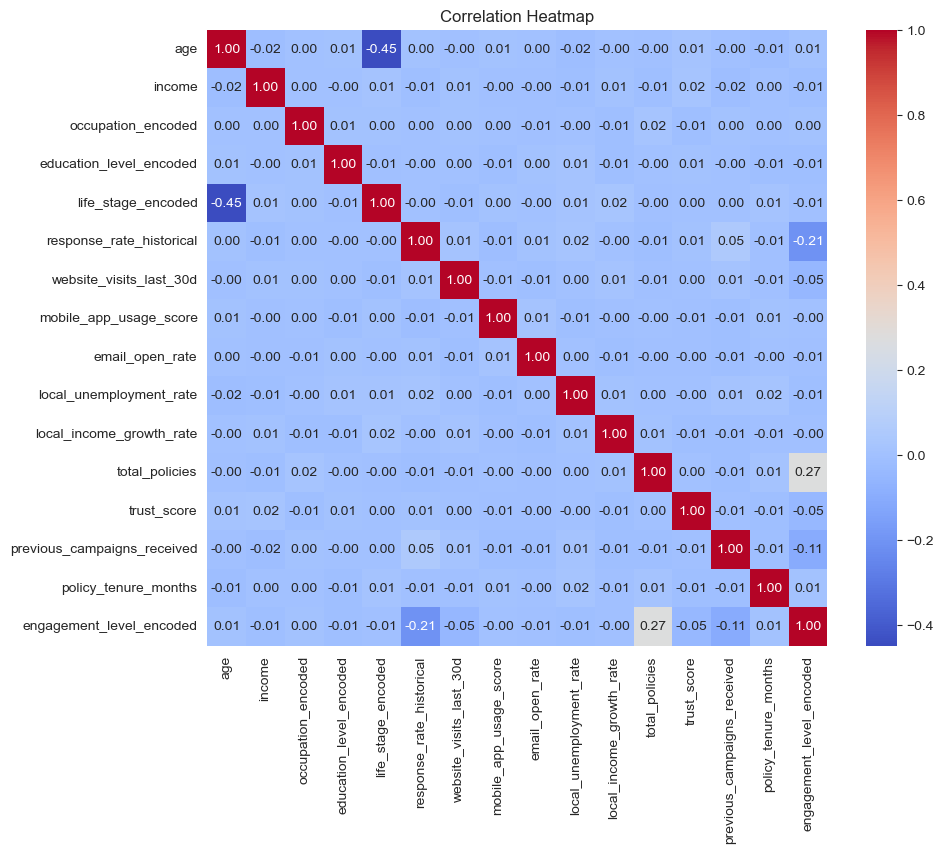

```python
import seaborn as sns
import matplotlib.pyplot as plt

plt.figure(figsize=(10,8))

df_heatmap=df_clean[[
    "age",
    "income",
    "occupation_encoded",
    "education_level_encoded",
    "life_stage_encoded",
    "response_rate_historical",
    "website_visits_last_30d",
    "mobile_app_usage_score",
    "email_open_rate",
    "local_unemployment_rate",
    "local_income_growth_rate",
    "total_policies",
    "trust_score",
    "previous_campaigns_received",
    "policy_tenure_months",
    "engagement_level_encoded"
]]
corr = df_heatmap.corr()
sns.heatmap(corr, cmap="coolwarm", annot=True, fmt=".2f")
plt.title("Correlation Heatmap")
plt.show()
```

"previous_campaigns_received" shows a weak positive correlation with "response_rate_historical" and a very weak negative correlation with "engagement_level_encoded." This suggests that customers who have historically responded more are more likely to be targeted with future campaigns.

## **3.1 Data Relationship Exploration: Customer Background**

Based on the information in 3.1 Customer Background, we draw visualizations of "Engagement Level by Age and Occupation," "Income Density for Engagement Level," and "Engagement Level by Education" to analyze the impact of age and occupation on the target population.

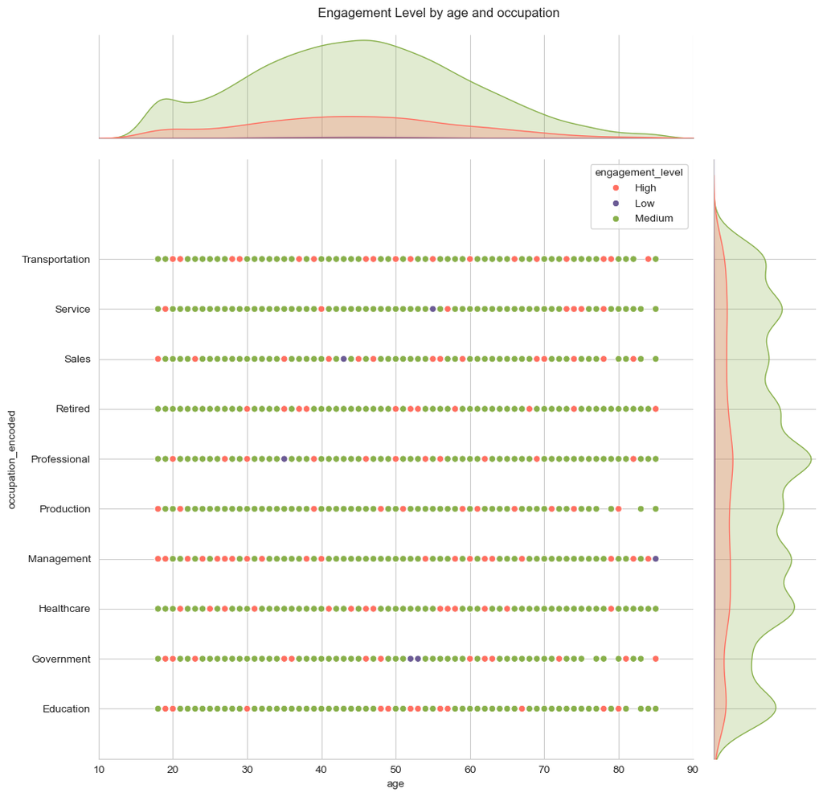

```python
custom_palette = ["#FF6F61", "#6B5B95", "#88B04B"]

plt.figure(figsize=(10,8))
g = sns.jointplot(
    data=df_clean,
    x="age",
    y="occupation_encoded",
    hue="engagement_level_encoded",
    palette=custom_palette,
    kind="scatter",
    height=10
)

# Limit the x-axis and y-axis range of the image to make it more beautiful
g.ax_joint.set_ylim(-1, 11)
g.ax_joint.set_xlim(10, 90)

occupation_map = dict(enumerate(df_clean["occupation"].astype("category").cat.categories))
# Set the y-axis label to the original occupation, not encoded
g.ax_joint.set_yticks(sorted(df_clean["occupation_encoded"].unique()))
g.ax_joint.set_yticklabels([occupation_map[val] for val in sorted(df_clean["occupation_encoded"].unique())])

# Get the legend and modify the labels
legend = g.ax_joint.get_legend()
legend.set_title("engagement_level")
# Original label mapping corresponding to hue encoding
engagement_map = dict(zip(df_clean["engagement_level_encoded"], df_clean["engagement_level"]))
for t, l_enc in zip(legend.get_texts(), sorted(df_clean["engagement_level_encoded"].unique())):
    t.set_text(engagement_map[l_enc])

plt.suptitle(f"Engagement Level by age and occupation", y=1.02)  # y -> Increase title position
plt.show()
```

Professional and Management: Customers in these occupations seem to have a slightly wider spread of High engagement dots (in red), particularly in the 30-to-50 age range. This might suggest that due to the nature of their work, these customers might be slightly more prone to higher engagement.

Government and Education: These two occupations appear to have a very high and consistent density of Medium engagement dots (in green). This could imply that customers in these fields tend to maintain a stable, moderate level of engagement, perhaps less prone to the extremes of being highly active or completely disengaged.

The key finding from this visualization is that neither age nor occupation is a strong predictor of a customer's engagement level.

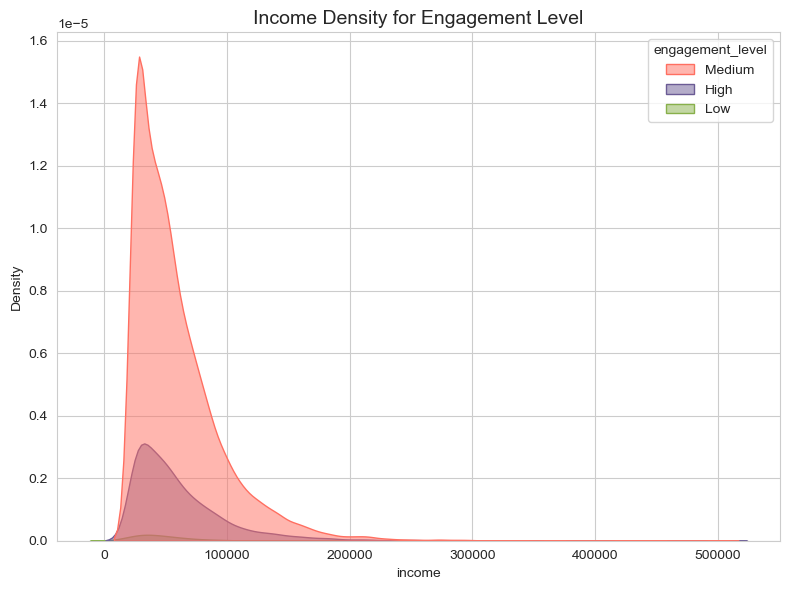

```python
plt.figure(figsize=(8,6))
sns.kdeplot(
    data=df_clean,
    x="income",
    hue="engagement_level",
    fill=True,
    palette=custom_palette,
    alpha=0.5
) # KDE curve (probability density)
plt.title("Income Density for Engagement Level", fontsize=14)
plt.tight_layout()
plt.show()
```

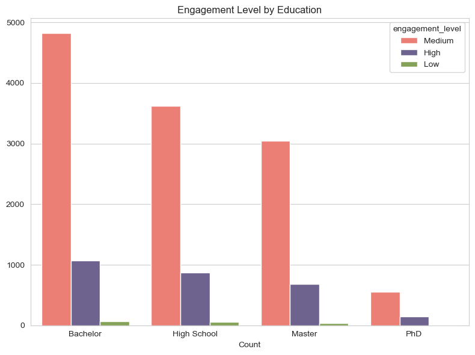

```python
plt.figure(figsize=(8,6))
sns.countplot(
    data=df_clean,
    x="education_level",
    hue="engagement_level",
    palette=custom_palette,
    order=df_clean["education_level"].value_counts().index  # Sort by quantity
)

plt.xlabel("Count")
plt.ylabel("")
plt.title("Engagement Level by Education")
plt.legend(title="engagement_level", loc='upper right')
plt.tight_layout()
plt.show()
```

Regardless of the customer's education level (Bachelor, High School, Master, or PhD), the number of "Medium" engagement customers significantly outweighs those with "High" or "Low" engagement.This indicates that the vast majority of your customer base is in a stable, average state of engagement—neither highly active nor completely disengaged. The green bars representing "Low" engagement are barely visible in the chart, this is a positive sign, as it shows that very few customers have completely lost interest

## **3.2 Data Relationship Exploration: Demographics**

In the second step, we analyzed the impact of the timing of customer contact with insurance on engagement_level.

Therefore, we draw visualizations such as "Engagement Level by Local Unemployment Rate", "Engagement Level by Local Income Growth Rate", and "Engagement Level by Timing (Life Stage and Response Rate)" to analyze whether these time-related characteristics affect the engagement_level.

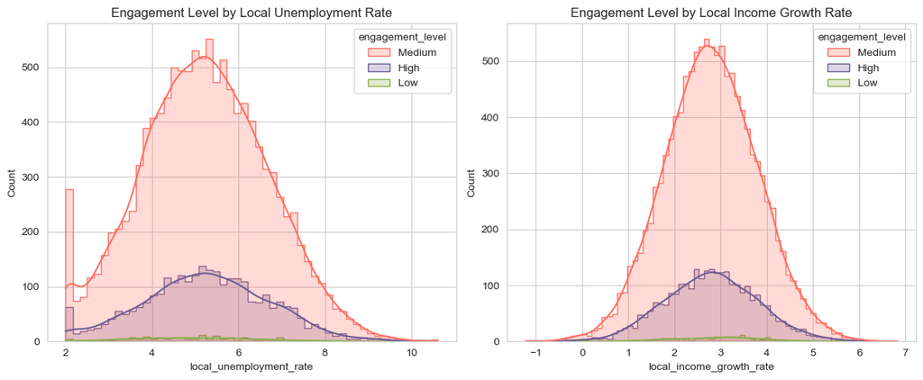

```python
fig, axes = plt.subplots(1, 2, figsize=(12, 5))  # 1 row and 2 columns
# The first subgraph：local_unemployment_rate
sns.histplot(
    data=df_clean,
    x="local_unemployment_rate",
    hue="engagement_level",
    palette=custom_palette,
    kde=True,
    element="step",
    ax=axes[0]
)
axes[0].set_title("Engagement Level by Local Unemployment Rate")

# The second subgraph：local_income_growth_rate
sns.histplot(
    data=df_clean,
    x="local_income_growth_rate",
    hue="engagement_level",
    palette=custom_palette,
    kde=True,
    element="step",
    ax=axes[1]
)
axes[1].set_title("Engagement Level by Local Income Growth Rate")

plt.tight_layout()
plt.show()
```

In both charts, the red curve and histogram bars representing "Medium" engagement are the tallest and have the widest spread. Regardless of the economic conditions in their area, there is no clear relationship between a customer's engagement level and the economic conditions of their location. Whether the local economy is struggling or thriving, customers' engagement tends to remain at a medium level.

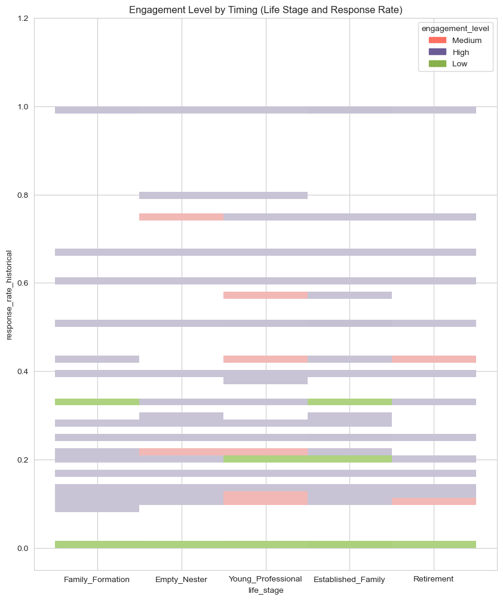

```python
plt.figure(figsize=(10,12))
sns.histplot(
    data=df_clean,
    x="life_stage",
    y="response_rate_historical",
    hue="engagement_level",
    palette=custom_palette,
    kde=True,
    element="step"
)
plt.ylim(-0.05, 1.2) # The legend does not block the content
plt.title("Engagement Level by Timing (Life Stage and Response Rate)")
plt.show()
```

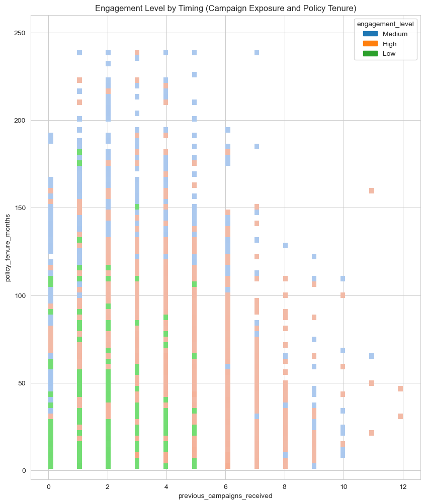

```python
plt.figure(figsize=(10,12))
sns.histplot(hue="engagement_level",
             x="previous_campaigns_received",
             y="policy_tenure_months",
             data=df_clean,
             kde=True,
             element="step")

plt.ylim(-5, 260) # The legend does not block the content
plt.title("Engagement Level by Timing (Campaign Exposure and Policy Tenure)")
plt.show()
```

## **3.3 Data Relationship Exploration: Behavior**

In the third step, we analyze the impact of customer behavior on their enthusiasm for participating in insurance.

We created visualizations of "Engagement Level by Digital Interaction Metrics" and "Engagement Level by (total_polocies and trust_score)" to analyze the impact of the corresponding features.

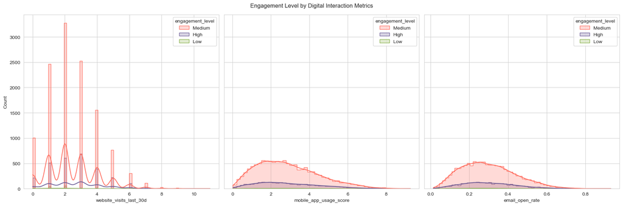

```python
fig, axes = plt.subplots(1, 3, figsize=(18,6), sharey=True)

features = ["website_visits_last_30d","mobile_app_usage_score","email_open_rate"]

for ax, feature in zip(axes, features):
    sns.histplot(
        data=df_clean,
        x=feature,
        hue="engagement_level",
        palette=custom_palette,
        kde=True,
        element="step",
        ax=ax
    )

# Overall title
plt.suptitle("Engagement Level by Digital Interaction Metrics")
plt.tight_layout()
plt.show()
```

Across digital interactions, Medium Engagement is still the most frequent pattern, showing up consistently in website visits, app usage, and email open rates. The High Engagement is still visible, but shown on a much smaller scale compared to High Engagement. Meanwhile, Lower Engagement does not show much prevalency. This suggests that even though customers interact digitally, the activity is leaning more towards a Medium Engagement level stabilization rather than leaning more towards an extreme side of Low or High.

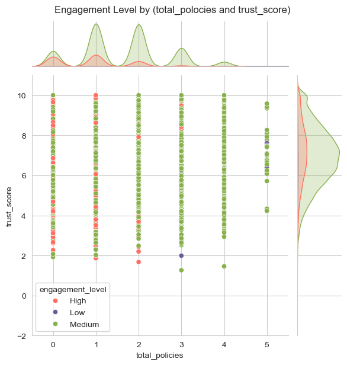

```python
g = sns.jointplot(
    data=df_clean,
    x="total_policies",
    y="trust_score",
    hue="engagement_level_encoded",
    palette=custom_palette,
    kind="scatter",
    height=6
)

g.ax_joint.set_xlim(-0.5, 5.5)
g.ax_joint.set_ylim(-2, 11)
# Get the legend and modify the labels
legend = g.ax_joint.get_legend()
legend.set_title("engagement_level")
# Original label mapping corresponding to hue encoding
engagement_map = dict(zip(df_clean["engagement_level_encoded"], df_clean["engagement_level"]))
for t, l_enc in zip(legend.get_texts(), sorted(df_clean["engagement_level_encoded"].unique())):
    t.set_text(engagement_map[l_enc])

g.fig.suptitle("Engagement Level by (total_polocies and trust_score)", y=1.02)
plt.show()
```

There is some High Engagement still prevalent, but it is scattered all over the lower Total Policy range. This pattern continues to trend when looking at Trust Score and Total Policies, where the Medium Engagement still dominates regardless of policy count or score. We can conclude that customer behavior tends to popularize towards stable and more moderate interaction.

## **4. Dimensionality Reduction**

## **4.1 Dimensionality reduction through UMap**

Now, we will use the **UMap** tool to reduce the dimensionality of the dataset to **2D** and **3D** for analysis.

```
Processing UMAP...
```

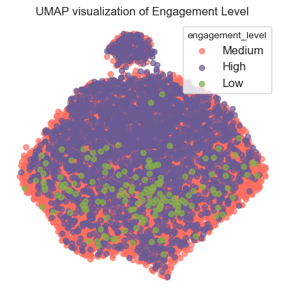

```python
from scipy.sparse import hstack
from sklearn.preprocessing import OneHotEncoder, StandardScaler
from torchdr import UMAP as torchdrUMAP

device='cuda'
# Prepare data
num_cols = [
    "age",
    "income",
    "response_rate_historical",
    "website_visits_last_30d",
    "mobile_app_usage_score",
    "email_open_rate",
    "local_unemployment_rate",
    "local_income_growth_rate",
    "trust_score",
    "previous_campaigns_received",
    "policy_tenure_months"
]
# Prepare One-Hot Encode
cat_cols = [
    "occupation",
    "education_level",
    "life_stage",
    "total_policies",
]

target_col = "engagement_level"

# data processing
df_sample = df.copy()
# df_sample = df.sample(frac=0.05, random_state=42)
df_num = df_sample[num_cols]
df_cat = df_sample[cat_cols]

# Feature processing
ohe = OneHotEncoder(sparse_output=False, handle_unknown="ignore")
df_cat_ohe = ohe.fit_transform(df_cat)

scaler = StandardScaler()
df_num_scaled = scaler.fit_transform(df_num)

# Convert continuous features to sparse and then concatenate
from scipy.sparse import csr_matrix
X_sparse = hstack([csr_matrix(df_num_scaled), df_cat_ohe])
X = X_sparse.toarray()

# Category Color
y, uniques = pd.factorize(df_sample[target_col])

print(f"Processing UMAP...")

plt.figure(figsize=(5, 5))

# torchdr UMAP
umap_model = torchdrUMAP(
    n_neighbors=10,
    min_dist=0.7,
    n_components=2,
    device='cuda',
    backend='pytorch'
)

embedding = umap_model.fit_transform(X)
X_umap = embedding

# Drawing
for k, label in enumerate(uniques):
    mask = (y == k)
    plt.scatter(
        X_umap[mask, 0], X_umap[mask, 1],
        color=custom_palette[k],
        alpha=0.7, s=30,
        label=label
    )

# Set title and legend
plt.title(f"UMAP visualization of Engagement Level", fontsize=12)
plt.legend(title="engagement_level", loc='upper right', fontsize=12)

# Remove the coordinate axis
plt.xticks([])
plt.yticks([])
plt.box(False)
plt.show()
```

This chart is a 2D UMAP visualization, showing the distribution of "Engagement Level" data on a two-dimensional plane. This plot illustrates the challenge in differentiating between the Medium and High engagement categories, as they appear to be part of one continuous behavior pattern. The Low engagement group, however, represents a more unique and scattered behavior, suggesting it's not closely related to the other two groups.

```
Processing UMAP_3D...
```

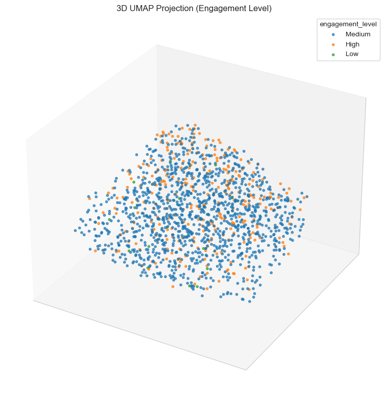

```python
import matplotlib.pyplot as plt


df_sample = df.sample(frac=0.1, random_state=42)
df_num = df_sample[num_cols]
df_cat = df_sample[cat_cols]

# Feature processing
ohe = OneHotEncoder(sparse_output=False, handle_unknown="ignore")
df_cat_ohe = ohe.fit_transform(df_cat)

scaler = StandardScaler()
df_num_scaled = scaler.fit_transform(df_num)

# Convert continuous features to sparse and then concatenate
from scipy.sparse import csr_matrix
X_sparse = hstack([csr_matrix(df_num_scaled), df_cat_ohe])
X = X_sparse.toarray()

# Category Color
y, uniques = pd.factorize(df_sample[target_col])

print(f"Processing UMAP_3D...")

# torchdr UMAP
umap_model = torchdrUMAP(
    n_neighbors=10,
    min_dist=0.7,
    n_components=3,
    device='cuda',
    backend='pytorch'
)
embedding = umap_model.fit_transform(X)
# Convert torchdrUMAP embedding to numpy
embedding_3d = np.array(embedding)

fig = plt.figure(figsize=(8, 8))
ax = fig.add_subplot(projection="3d")

labels = uniques  # The original category name after factorization
for i, label in enumerate(labels):
    idx = y == i
    # 散点图
    sc = ax.scatter(
        embedding_3d[idx, 0],
        embedding_3d[idx, 1],
        embedding_3d[idx, 2],
        s=10,
        alpha=0.7,
        label=label
    )

# Axis labels and ticks
ax.set_xlabel("")
ax.set_ylabel("")
ax.set_zlabel("")
ax.set_xticks([])
ax.set_yticks([])
ax.set_zticks([])
ax.set_title("3D UMAP Projection (Engagement Level)")

ax.legend(title="engagement_level", loc="best")

plt.tight_layout()
plt.show()
```

The chart is a 3D UMAP Projection that visualizes data points related to "Engagement Level." The plot shows how the different engagement levels are distributed relative to each other. We can see that the Medium and High engagement levels are fairly intermixed and form a large central cluster, while the Low engagement points are scattered more sparsely throughout the projection. This suggests that the features used to define engagement for "Medium" and "High" are similar, but "Low" engagement may have a less predictable or more varied pattern.

## **4.2 Dimensionality reduction through PCA**

```
The variance explained by PCA: [0.14582652 0.1363028 ]
Component weights (coefficients):
     response_rate_historical  website_visits_last_30d  \
PC1                 -0.149656                 0.055678
PC2                  0.634054                 0.075773

     mobile_app_usage_score  email_open_rate  trust_score  \
PC1                0.103323         0.023253     0.676999
PC2               -0.051403         0.014570     0.156432

     previous_campaigns_received  policy_tenure_months  total_policies  \
PC1                    -0.037931              0.023760        0.032319
PC2                     0.254503             -0.029526       -0.015884

     previous_responses  quote_requests_last_year  quote_completion_rate  \
PC1           -0.160396                 -0.099680              -0.019592
PC2            0.673194                 -0.083403              -0.002848

     service_calls_last_year  claims_last_3_years  trust_score
PC1                -0.013537             0.085755     0.676999
PC2                -0.089024            -0.080388     0.156432
```

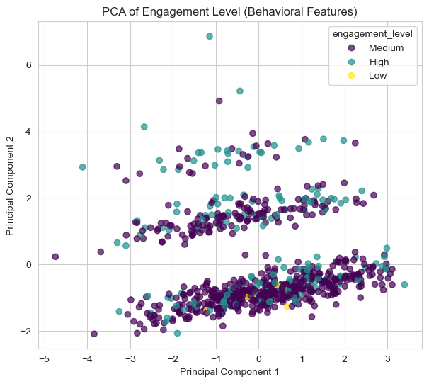

```python
from sklearn.decomposition import PCA

df = pd.read_csv("hf://datasets/nprak26/insurance-campaign-data/insurance_campaign_data_original_20250720_140142.csv")
df_clean = df.copy()

# Select Features
feature_cols = [
    "response_rate_historical",
    "website_visits_last_30d",
    "mobile_app_usage_score",
    "email_open_rate",
    "trust_score",
    "previous_campaigns_received",
    "policy_tenure_months",
    "total_policies",
    "previous_responses",
    "quote_requests_last_year",
    'quote_completion_rate',
    'service_calls_last_year',
    'claims_last_3_years',
    "trust_score",
]

target_col = "engagement_level"

for col in feature_cols:
    df_clean.loc[:, col] = pd.to_numeric(df_clean[col], errors='coerce')

df_clean.dropna(subset=feature_cols + [target_col], inplace=True)

df_clean = df_clean.sample(frac=0.05, random_state=42)

X = df_clean[feature_cols]
y = df_clean[target_col]


scaler = StandardScaler()
X_scaled = scaler.fit_transform(X)

pca = PCA(n_components=2)
X_pca = pca.fit_transform(X_scaled)

print("The variance explained by PCA:", pca.explained_variance_ratio_)
print("Component weights (coefficients):")
pca_components_df = pd.DataFrame(pca.components_, columns=feature_cols, index=['PC1', 'PC2'])
print(pca_components_df)

y_codes, uniques = pd.factorize(y)

plt.figure(figsize=(7, 6))

scatter = plt.scatter(X_pca[:, 0], X_pca[:, 1], c=y_codes, cmap="viridis", alpha=0.7)

plt.xlabel("Principal Component 1")
plt.ylabel("Principal Component 2")
plt.title("PCA of Engagement Level (Behavioral Features)")

plt.legend(handles=scatter.legend_elements()[0], labels=list(uniques), title="engagement_level")
plt.show()
```

We sample randomly 5% of the observations from the data set to have better visualization after PCA. We've tried changing all the features to be behavior-based, but the conclusion is still the same: they can't be distinguished. The purple "Medium Engagement" group and the blue-green "High Engagement" group largely overlap. This shows that it's difficult to distinguish between these two groups based on behavioral features alone.While the yellow "Low Engagement" group is very small (barely visible in the chart), these points are scattered among the other two groups and do not form a separate cluster.

## **5. Conclusion**

Customer engagement patterns are highly concentrated and stable: Analysis shows that the vast majority of customers (regardless of demographic background, economic environment, or behavioral patterns) are at a "Medium" engagement level. This is a positive sign, indicating an overall stable customer base, but it also means that significantly increasing overall engagement (moving to "High") or preventing customer churn (moving to "Low") will be challenging.

The limited predictive power of single factors: Whether it's demographic factors like age, occupation, income, or education level; economic factors like local unemployment rate and income growth rate; or digital interactions like website visits, app usage, and email open rates, no single characteristic can strongly predict customer engagement levels. Customer engagement behavior is a complex outcome influenced by multiple factors.

Highly engaged and moderately engaged customers have similar characteristics: UMAP and PCA dimensionality reduction analysis clearly show that "Highly" and "Mediumly" engaged customers have significant overlap in feature space, making it difficult to clearly distinguish. This suggests that the factors driving high engagement may be similar to those that maintain moderate engagement, but differ in degree or combination.

“Low Engagement” Customers Have Unique but Rare Behavior Patterns: While low in number, low-engagement customers exhibit more dispersed and unique patterns in the dimensionality reduction plot. This suggests that their reasons for churn are likely diverse, rather than stemming from a common, distinct characteristic.

## **Reference**

> nishanth prakash, "insurance_campaign_data",Hugging Face, 2025, https://huggingface.co/datasets/nprak26/insurance-campaign-data